# Hop Cultivar Analysis

# Introduction

Typically, I will think about hopping with a style archetype in mind, I will survey a list of hops, read about the attributes, chemical compositions and then choose the hop bill. I seldom think about the universe of hop cultivars as a whole and what meta-profile it might have. For this note, I will look at aggregate features of multiple cultivars with a focus on the top of the hop taxonomy, purpose, which can be either bittering, aroma or dual-purpose. Can we analytically determine the purpose of a hop using it’s chemical composition? The simple answer is, of course, “yes.” High-alpha cultivars are usually bittering hops. The purpose of this exercise is not to discover the obvious but to explore the techniques we can bring to bear to do meta-analysis and visualization on large data sets of brewing information.

Getting the data and putting it into analyzable form is the biggest part of these projects. We need nice tables of data but often we have unstructured or semi-structured text. We are in luck today because the good folks at [brewcabin.com](https://www.brewcabin.com/hop-varieties/) have put the data from 147 hop cultivars into a publicly accessible Google spreadsheet that we can easily import.

Less structured data is more of a pain but do-able. The source for much of the hops spreadsheet was information from Yakima Chief Hops. I assume they hand scraped [this PDF file](https://www.yakimachief.com/wp-content/uploads/Yakima_Chief_Hops_Varieties_19.02.04.pdf) but we could build a robot to do it (with permission, of course). You can look at a [project I did here](https://outsiderdata.netlify.app/post/is-free-pre-k-in-nyc-favoring-the-rich/) for an example of data scraping from within PDF files.

The format of this note is a data science notebook. The code to replicate the work and present all the data is presented along with the descriptive text. In the web page version there is a button at at the top labeled “code” which you can use to toggle code visibility on or off. I recommend you turn code visibility “off” to begin with. This is more readable that way.

# Load the data from the spreadsheet

```r
# Hop analysis demo

library(tidyverse)
library(tidytext)
library(reshape2)
library(ggridges)
library(here)
library(pdftools)
library(googlesheets4)
# ML Libraries
library(tidymodels)
library(tidypredict)
library(randomForest)
library(vip)
library(rpart)
library(h2o)
# source: brewcabin.com and yakima chief hops

if (file.exists(here("data","hops_raw.rdata"))){
  load(here("data","hops_raw.rdata"))
} else {
  sheet <- "https://docs.google.com/spreadsheets/d/1qNedHmXqhqzpqt1vgzjUJ0NYtY_7Lov_Vue_k_hZPf8/edit#gid=1675045246"
  # public sheet so we don't neet authorization
  googlesheets4::gs4_deauth()
  hops_raw <- read_sheet(sheet,sheet="Hops (Uploaded)",
                         col_types = "ccciiiiiiiiiiiiiiccccccc") %>%
    mutate(Origin = as.factor(Origin),Type = as.factor(Type))

  save(hops_raw,file=here("data","hops_raw.rdata"))
}

hops_raw
```

| Variety | Origin | Type | Alpha Acid LOW (%) | Alpha Acid HIGH (%) | Beta Acid LOW (%) | Beta Acid HIGH (%) | Total Oil LOW (mL/100g) | Total Oil HIGH (mL/100g) | Co-Humulone LOW (%) | Co-Humulone HIGH (%) | Myrcene LOW (% of total oil) | Myrcene HIGH (% of total oil) | Caryophyllene LOW (% of total oil) | Caryophyllene HIGH (% of total oil) | Humulene LOW (% of total oil) | Humulene HIGH (% of total oil) | Farnesene (% of total oil) | Description (ychhops.com) | Aroma (ychhops.com) | Beer Styles | Substitutions | Sources (DO NOT IMPORT)...23 | Sources (DO NOT IMPORT)...24 |
| --- | --- | --- | --- | --- | --- | --- | --- | --- | --- | --- | --- | --- | --- | --- | --- | --- | --- | --- | --- | --- | --- | --- | --- |
| Ahtanum® | United States | Aroma | 5 | 6 | 5 | 6 | 0 | 1 | 30 | 35 | 50 | 55 | 9 | 12 | 16 | 20 | < 1 | Bred by Select Botanicals Group, Ahtanum® Brand YCR 1 is an aroma-type cultivar used for its aromatic properties and moderate bittering. The hop is named after the location where Charles Carpenter est… | citrus grapefruit and geranium. | India Pale Ale, Pale Ale, Heffeweisen, American Ales, Lagers, Californian Common, Bitters | Cascade, Amarillo®, Simcoe®, Centennial, Willamette | NA | NA |
| Amarillo® | United States | Aroma | 8 | 11 | 6 | 7 | 1 | 1 | 21 | 24 | 68 | 70 | 2 | 4 | 9 | 11 | 2 - 4 | Discovered and introduced by Virgil Gamache Farms in Washington State, Amarillo® Brand VGXP01 cv. is an aroma variety that has recently become one of the top 10 varieties utilized by the craft beer in… | grapefruit, orange, lemon, melon, apricot and peach. | American Wheat, American Pale Ale, American IPA, Amber Wheat Beers | Cascade, Centennial, Simcoe | NA | NA |
| Aramis | France | Aroma | 7 | 8 | 3 | 4 | 1 | 1 | 20 | 21 | 39 | 41 | 7 | 7 | 20 | 21 | 2 - 4 | Closely resembling Strisselspalt, but with higher oil and alpha content, Aramis is the first variety from the Comptoir Agricole breeding program. | spicy, herbal and subtle citrus. | Pilsner, Lager, Wheat, Saison, India Pale Ale, Belgian Ales, Pale Ale, Porter | Willamette, Challenger, Ahtanum\231, Strisselspalter, Centennial, Chinook, Hallertau, Tettnang | NA | NA |
| Aurora | Slovenia | Aroma | 7 | 8 | 2 | 4 | 0 | 1 | 20 | 26 | 20 | 25 | 6 | 9 | 20 | 25 | 5 - 10 | A diploid hybrid of Northern Brewer and a TG seedling of unknown origin, Aurora displays an intense yet pleasant aroma in finished beers. It is also known as Super Styrian. | noble characteristics. | American Pale Ale, Dark Lager | Styrian Golding, Northern Brewer | NA | NA |
| Blanc | Germany | Aroma | 9 | 12 | 4 | 5 | 1 | 1 | 22 | 26 | 50 | 75 | 0 | 2 | 0 | 3 | < 1 | Released in 2012, Hallertau Blanc is one of several new German varieties with bold flavor profiles, perfect for American-style Ales. | floral and fruity with passion fruit, grapefruit, pineapple, grape and lemongrass overtones. | American IPAs, American Ales | Nelson Sauvin | NA | NA |
| Bobek | Slovenia | Aroma | 3 | 7 | 4 | 6 | 0 | 4 | 27 | 31 | 30 | 45 | 4 | 6 | 13 | 19 | 4 - 7 | A world-renowned couplet with moderate bitterness. | intense and pleasant with floral and pine overtones. | English Ale, Extra Special Bitter, Lager, Pilsner | Fuggle, Willamette, Styrian Golding | NA | NA |
| Brewers Gold | Germany | Aroma | 5 | 8 | 2 | 3 | 1 | 2 | 40 | 48 | 37 | 40 | 7 | 8 | 29 | 31 | < 1 | Originally bred in the United Kingdom by professor E.S. Salmon, Brewer's Gold has a high resin content and gives a well-balanced bitterness which is ideally complemented by late hop additions in lager… | blackcurrant, fruity, and spicy | Ale, American Pale Ale, Bitter, Barley Wine, Imperial Stout | Bullion, Cascade, Galena, Northern Brewer (US), Northdown | NA | NA |
| Cascade | United States | Aroma | 5 | 9 | 6 | 7 | 0 | 2 | 30 | 35 | 45 | 60 | 5 | 9 | 14 | 20 | 6 - 9 | Originating from the USDA-ARA breeding program, Cascade is an aroma-type cultivar bred in 1956 and released in 1972. It was developed by open pollination of a Fuggle seedling. Cascade is the most popu… | Medium intense floral, citrus and grapefruit tones | Pale ale, IPA, porter, barleywine | Centennial, Amarillo, Columbus | NA | NA |
| Citra® | United States | Aroma | 11 | 15 | 3 | 4 | 1 | 3 | 20 | 24 | 60 | 70 | 5 | 8 | 7 | 12 | < 1 | Developed by Hop Breeding Company and released in 2007. Citra® Brand HBC 394 features fairly high alpha acids and total oil contents with a low percentage of co-humulone. It is tolerant to downy milde… | grapefruit, melon, lime, gooseberry, passion fruit and lychee | American Pale Ale, American IPA, Double IPA, Amber Ale | Simcoe, Mosaic | NA | NA |
| Crystal | United States | Aroma | 2 | 4 | 4 | 6 | 1 | 1 | 20 | 26 | 45 | 60 | 4 | 8 | 18 | 24 | < 1 | Bred in 1983 by the USDA, Crystal is a triploid aroma-type cultivar from Hallertau Mittelfrüh, Cascade, Brewer's Gold and Early Green. It is primarily grown in Oregon and has become increasingly popul… | woody and green | Bitter, Pilsner, Light Lager, Golden Ale, Nut Brown Ale, Pale Ale, India Pale Ale, Stout, Chocolate Stout, American Lager | Liberty, Mount Hood, German Hallertau, Ultra, Strisselspalter, Hersbrucker | NA | NA |

[output cut: 137 more lines]

# Clean up the Data

While importing the spreadsheet is easy the data still needs a lot of cleaning up. The chemical constituents are expressed as high and low ranges. I choose to condense them into average values. Further the words used to describe qualitative attributes like aroma and beer style are inconsistent. Are “citrusy” and “citrus” the same thing? Misspellings are common, German words, especially. We also strip out “stop words” like “and”,“the”,“lots”, etc, that don’t really say anything. Fixing these is a tedious art but critical to success. This part is actually the bulk of the code and uses the most run time in the notebook. One thing that’s confusing about our cleaned data is that I’ve embeded all the descriptive terms as lists in single columns. That will be make running our models easier.

```r
# DATA CLEANING
# tidy up names
# =============================================================
tidy_names <- function(col_names){
  col_names <- tolower(col_names) %>%
    str_replace_all(c(" " = "_" , "," = "" )) %>%
    str_replace_all("\\(%\\)","pct") %>%
    str_replace_all("\\(ml\\/100g\\)","ml_per_100g") %>%
    str_replace_all("\\(%_of_total_oil\\)","oil_fraction") %>%
    str_remove_all("_\\(ychhops.com\\)") %>%

    {.}
  return(col_names)
}

# function to handle range strings like "1 - 2" or "< 1"
# < 1 is treated as 0.5
str_parse_range <- Vectorize(function(range_str){
  frac_reg <- "(0|[1-9]\\d*)?(\\.\\d+)?(?<=\\d)"
  value = NA
  if(is.na(range_str)) return(NA)
  if(str_detect(range_str,paste0(frac_reg," - ",frac_reg))){
    values = str_extract_all(range_str,frac_reg)
    value = (as.numeric(values[[1]][1]) + as.numeric(values[[1]][3]))/2
  }
  if(str_detect(range_str,"< 1")){
    value = 0.5
  }
  return(value)
} )

hops_clean <- hops_raw %>%
  select(-starts_with("sources")) %>%
  rename_with(tidy_names)

# INITIALIZE hops DATA FRAME
# --------------------------------------

# make a data set with just averages of high/low component ranges
# is this representative of the true averages for these cultivars?
# we don't know
hops <- hops_clean %>% group_by(variety) %>%
  transmute(variety,
            type,
           origin,
           beer_styles,
           aroma,
           substitutions,
           alpha=mean(c_across(contains("alpha"))),
         beta=mean(c_across(contains("beta"))),
         cohumulone=mean(c_across(contains("co-humulone"))),
         myrcene=mean(c_across(contains("myrcene"))),
         caryophyllene=mean(c_across(contains("caryophyllene"))),
         humulene=mean(c_across(contains("humulene"))),
         farnesene = str_parse_range(farnesene_oil_fraction),
         total_oil=mean(c_across(starts_with("total_oil")))
  ) %>%
  ungroup()

# --------------------------------------------
# get all the aroma words

# unhelpful aroma descriptors.
brew_stop_words <- tibble(word = c("aromas","aroma","mild","pleasant","characteristics",
                    "american","exceptional","exceptionally","Flavor",
                    "complement","intense","balance","complex","notes",
                    "top","tones","overtones","understated","lots",
                    "needles","clean","cut","crushed","hints",
                    "character","characters","flavor","hop",
                    "undercurrents"),
                    lexicon = "brewing")
# --------------------------------------------
# custom word stemmer
# i.e. wood, woody and woodsy become wood
brew_stem_words <-
  tribble(
    ~term, ~stem,
    "woodsy","wood",
    "woody","wood",
    "piney","pine",
    "earthy","earth",
    "resinous","resin",
    "zesty","zest",
    "zested","zest",
    "bittering","bitter",
    "bitterness","bitter"
  )

brew_stem_words <-
  tribble(
    ~term, ~stem,
    "woodsy","wood",
    "woody","wood",
    "piney","pine",
    "earthy","earth",
    "resinous","resin",
    "zesty","zest",
    "zested","zest",
    "bittering","bitter",
    "bitterness","bitter"
  )
stem <- Vectorize(function(term) {
  i <- match(term, brew_stem_words$term)
  if (is.na(i)) {
    stem <- term
  } else {
    stem <- brew_stem_words$stem[[i]]
  }
  return(stem)
})

hops_aromas <- hops_clean %>%
  select(variety,aroma) %>%
  mutate(aroma = tolower(aroma)) %>%
  tidytext::unnest_tokens("aroma","aroma") %>%
  filter(!(aroma %in% stop_words$word)) %>%
  filter(!(aroma %in% brew_stop_words$word)) %>%
  mutate(aroma = stem(aroma)) %>%
  # remove_missing() %>%
  mutate(aroma = as.factor(aroma)) %>%
  {.}

# Since "noble" is an aroma word of some non-noble hops,
# make sure that is an attribute of actual noble hops
# German Hallertauer Mittelfrüh, Tettnang, Spalt and Czech Saaz
appendix <- tribble(
  ~variety,~aroma,
  "Saaz","noble",
  "Spalter","noble",
  "Spalter Select","noble",
  "Hallertauer Mittelfrüh","noble"
  )
hops_aromas <- bind_rows(hops_aromas,appendix) %>%
  mutate(aroma = as_factor(aroma))

# Put the word vectors back into the data as lists
hops <- hops %>%
  select(-aroma) %>%
  left_join(nest(hops_aromas,aroma=aroma),by="variety")
# --------------------------------------------
# get all the style names
# and bring some consistency to them.  Ugh.
hops_styles <- hops_clean %>%
  select(variety,beer_styles) %>%
  tidytext::unnest_tokens("beer_styles","beer_styles",
                          token="regex",pattern="\n|,|&") %>%
  mutate(beer_styles = trimws(beer_styles)) %>%
  filter(!(beer_styles %in% stop_words$word)) %>%
  mutate(beer_styles = str_replace(beer_styles,"('s|s)$","")) %>%
  mutate(beer_styles = str_replace(beer_styles,"india pale ale","ipa")) %>%
  mutate(beer_styles = str_replace(beer_styles,"extra special bitter","esb")) %>%
  mutate(beer_styles = str_replace(beer_styles,"kolsch","kölsch")) %>%
  mutate(beer_styles = str_replace(beer_styles,"pilsener lagers\\.|pilsner","pilsener")) %>%
  mutate(beer_styles = str_remove(beer_styles,"-style")) %>%
  mutate(beer_styles = str_remove(beer_styles,"/[a-z]+")) %>%
  mutate(beer_styles = str_remove(beer_styles,"\\*")) %>%
  mutate(beer_styles = str_remove(beer_styles," beer")) %>%
  mutate(beer_styles = str_remove(beer_styles," (esb)")) %>%
  mutate(beer_styles = str_replace(beer_styles,"us ","american ")) %>%
  mutate(beer_styles = ifelse(str_detect(beer_styles,"wei"),"hefeweizen",beer_styles)) %>%
  mutate(beer_styles = ifelse(str_detect(beer_styles,"borwn"),"brown ale",beer_styles)) %>%
  mutate(beer_styles = as.factor(beer_styles)) %>%
  {.}

# Put the word vectors back into the data.
hops <- hops %>%
  select(-beer_styles) %>%
  left_join(nest(hops_styles,beer_styles=beer_styles),by="variety")

# --------------------------------------------
# get all the substitute names
# big trouble with German spellings. Make consistent
hops_subs <- hops_clean %>%
  select(variety,substitutions) %>%
  tidytext::unnest_tokens("substitutions","substitutions",
                          token="regex",pattern="\n|,|&") %>%
  filter(!(substitutions %in% stop_words$word)) %>%
  filter(!(substitutions %in% c("??"))) %>%
  mutate(substitutions = str_replace(substitutions,"'s","s")) %>%
  mutate(substitutions = str_replace(substitutions,"haller[a-z]+","hallertau")) %>%
  mutate(substitutions = str_replace(substitutions,"tett[a-z]+","tettnanger")) %>%
  mutate(substitutions = str_replace(substitutions,"mt(.)? ","mount ")) %>%
  mutate(substitutions = str_remove(substitutions,"®|™")) %>%
  mutate(substitutions = str_remove(substitutions,"variety")) %>%
  mutate(substitutions = str_replace(substitutions,"goldings","golding")) %>%
  mutate(substitutions = str_replace(substitutions,"^kent","east kent")) %>%
  mutate(substitutions = str_replace(substitutions,"spalter","spalt")) %>%
  mutate(substitutions = str_replace(substitutions,"willametter","willamette")) %>%
  mutate(substitutions = str_replace(substitutions,"herkules","hercules")) %>%
  # get rid of origins to simplify. Some may not agree with this decision
  mutate(substitutions = str_remove(substitutions,"( )?\\([a-z]+\\)")) %>%
  mutate(substitutions = str_remove(substitutions,"us |uk |u\\.s\\. |u\\.k\\. ")) %>%
  mutate(substitutions = str_trim(substitutions)) %>%
  filter(!str_detect(tolower(variety),substitutions)) %>%
  mutate(substitutions = as.factor(substitutions)) %>%
  {.}

# Put the word vectors back into the data.
hops <- hops %>%
  select(-substitutions) %>%
  left_join(nest(hops_subs,substitutions=substitutions),by="variety")

hops
```

| variety | type | origin | alpha | beta | cohumulone | myrcene | caryophyllene | humulene | farnesene | total_oil | aroma | beer_styles | substitutions |
| --- | --- | --- | --- | --- | --- | --- | --- | --- | --- | --- | --- | --- | --- |
| Ahtanum® | Aroma | United States | 5.50 | 5.50 | 32.50 | 52.50 | 10.50 | 18.00 | 0.5 | 0.50 |  |  |  |
| Amarillo® | Aroma | United States | 9.50 | 6.50 | 22.50 | 69.00 | 3.00 | 10.00 | 3.0 | 1.00 |  |  |  |
| Aramis | Aroma | France | 7.50 | 3.50 | 20.50 | 40.00 | 7.00 | 20.50 | 3.0 | 1.00 |  |  |  |
| Aurora | Aroma | Slovenia | 7.50 | 3.00 | 23.00 | 22.50 | 7.50 | 22.50 | 7.5 | 0.50 |  |  |  |
| Blanc | Aroma | Germany | 10.50 | 4.50 | 24.00 | 62.50 | 1.00 | 1.50 | 0.5 | 1.00 |  |  |  |
| Bobek | Aroma | Slovenia | 5.00 | 5.00 | 29.00 | 37.50 | 5.00 | 16.00 | 5.5 | 2.00 |  |  |  |
| Brewers Gold | Aroma | Germany | 8.00 | 3.75 | 44.00 | 45.50 | 8.75 | 22.50 | 0.5 | 1.75 |  |  |  |
| Cascade | Aroma | United States | 7.00 | 6.50 | 32.50 | 52.50 | 7.00 | 17.00 | 7.5 | 1.00 |  |  |  |
| Citra® | Aroma | United States | 13.00 | 3.50 | 22.00 | 65.00 | 6.50 | 9.50 | 0.5 | 2.00 |  |  |  |
| Crystal | Aroma | United States | 3.00 | 5.00 | 23.00 | 52.50 | 6.00 | 21.00 | 0.5 | 1.00 |  |  |  |

[output cut: 137 more lines]

# Exploratory Data Analysis (EDA)

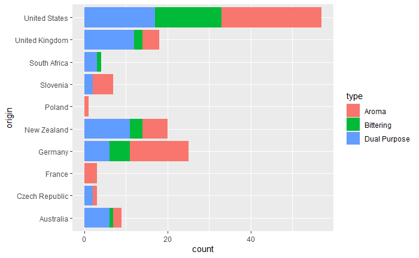

```r
# =============================================================
#  EXPLORATORY DATA ANALYSIS
# show origins of hops
hops %>% ggplot(aes(origin,fill=type)) + geom_bar() +
  coord_flip()
```

Every brewer knows that high alpha hops are for bittering. Let’s demonstrate this.

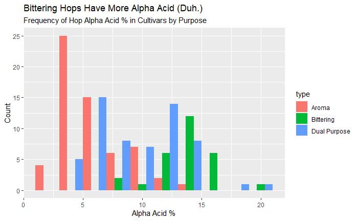

Most of the green bars (bittering) have more than 10% alpha acids and most of the red bars (aroma) have less. This chart could be clearer. Let’s do a “density” plot instead.

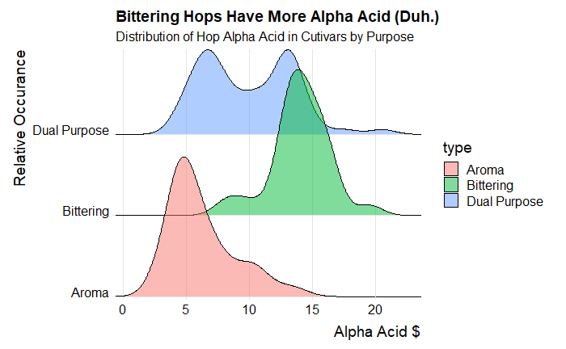

```r
# better visualization
hops %>% ggplot(aes(x=alpha,y=type,fill=type)) +
  # geom_density(alpha=0.5) +
   geom_density_ridges(alpha=0.5) +
  scale_y_discrete(expand = c(0, 0)) +     # will generally have to set the `expand` option
  scale_x_continuous(expand = c(0, 0)) +   # for both axes to remove unneeded padding
  coord_cartesian(clip = "off") + # to avoid clipping of the very top of the top ridgeline
  theme_ridges() +
  labs(title="Bittering Hops Have More Alpha Acid (Duh.)",
       subtitle= "Distribution of Hop Alpha Acid in Cutivars by Purpose",
       y = "Relative Occurance",
       x = "Alpha Acid $")
```

This is a much more pleasing plot and actually reveals a surprise. Dual purpose hops are not spread evenly across the alpha acid spectrum but are bi-modally distributed. Is this because growers select for bittering or aroma and brewers put the dual purpose label on later?

```r
# Now oils
  hops %>% ggplot(aes(x=total_oil,y=type,fill=type)) +
    # geom_density(alpha=0.5) +
    geom_density_ridges(alpha=0.5) +
    scale_y_discrete(expand = c(0, 0)) +     # will generally have to set the `expand` option
    scale_x_continuous(expand = c(0, 0)) +   # for both axes to remove unneeded padding
    coord_cartesian(clip = "off") + # to avoid clipping of the very top of the top ridgeline
    theme_ridges() +
    labs(title= "Distribution of Hop Total Oils by Purpose",
         y = "Relative Occurance",
         x = "Total Oil Range")
  NULL

# plot alpha vs oil by bittering type
hops %>%
  filter(type != "Dual Purpose") %>%
  ggplot(aes(alpha,total_oil)) +
  geom_point(aes(color=type,shape=type)) +
  geom_smooth(method = "lm",se=FALSE,color = "black")

hops %>%
  ggplot(aes(alpha,total_oil)) +
  geom_point(aes(color=type,shape=type)) +
  geom_smooth(method = "lm",se=FALSE,color = "black")

# use K-means to create three clusters using alpha and oil
hop_type <- hops %>%
  ungroup() %>%
#  filter(type != "Dual Purpose") %>%
  select(-variety) %>%
#  select(alpha_acid_mean,total_oil_mean) %>%
  mutate(cluster = as.character(kmeans(cbind(alpha,total_oil),centers=3)$cluster))


# plot alpha vs oil by bittering type
hop_type %>%
  ggplot(aes(alpha,total_oil,color=cluster,shape=type)) +
  geom_point()

# -----------------------------------------------
# Plot Ranges of components
# make data long first

hops %>% pivot_longer(names_to = "component",cols=where(is.double)) %>%
  filter(component %in% c("alpha","beta")) %>%
  ggplot(aes(component,value,color=type)) + geom_boxplot() +
  stat_summary(fun=mean, geom="point", shape=23, size=4) +
  scale_x_discrete(labels=c("Alpha","Beta")) +
#  coord_flip() +
  labs(x="Acids (%)",y="Quantity") +
  facet_grid(~type)

hops %>% pivot_longer(names_to = "component",cols=where(is.double)) %>%
  filter(component %in% c("cohumulone")) %>%
  ggplot(aes(component,value,color=type)) + geom_boxplot() +
  stat_summary(fun=mean, geom="point", shape=23, size=4) +
  scale_x_discrete(labels=c("")) +
  labs(x="Co-humulone",y="Percent of Alpha Acids") +
  facet_grid(~type)

hops %>% pivot_longer(names_to = "component",cols=where(is.double)) %>%
  filter(component %in% c("total_oil")) %>%
  ggplot(aes(component,value,color=type)) + geom_boxplot() +
  stat_summary(fun=mean, geom="point", shape=23, size=4) +
  scale_x_discrete(labels=c("")) +
  labs(x="Total Oil (mg/100g)",y="Quantity") +
  facet_grid(~type)

# not much here
hops %>% pivot_longer(names_to = "component",cols=where(is.double)) %>%
  filter(!(component %in% c("alpha","beta","total_oil","cohumulone"))) %>%
  ggplot(aes(component,value,color=type)) + geom_boxplot() +
  stat_summary(fun=mean, geom="point", shape=23, size=4) +
  facet_grid(~type) +
  coord_flip() +
  labs(x="Oil",y="Percent of Total Oil")

# -----------------------------------------
# show descriptors by popularity

# show style popularity
hops_styles %>%
  count(beer_styles) %>%
  arrange(desc(n)) %>%
  head(20) %>%
  ggplot(aes(fct_reorder(beer_styles,n),n)) + geom_col() +
  coord_flip() +
  labs(x= "Beer Style",y="Suggested Hop Cultivars")

# show popular descriptions for aromas
hops_aromas %>%
  count(aroma) %>%
  arrange(desc(n)) %>%
  head(20) %>%
  ggplot(aes(fct_reorder(aroma,n),n)) + geom_col() +
  coord_flip() +
  labs(x= "Aroma",y="Hop Cultivars With that Descriptor")
```

[output not shown]